# Assignment 3

Group 4

# Instructions

Consider the stochastic process of spread of an epidemics (of COVID-19, influenza, or other similar viruses) in a population composed by N individuals. Assume that each individual at each time step can be in one of the following 3 states: - S = susceptible = not infected and not immune (then s/he can be infected) - I = infected - R = removed = recovered and immune, or dead

Assume also that: - at each time step each susceptible individual becomes infected with probability 0.08 - each infected individual is removed with probability 0.6 - each removed individual returns back to be susceptible with probability 0.1.

Represent the evolution of the epidemics as a Markov chain and write the transition matrix.

Imagine now that the number N of individuals in the population is N = 10000.

If is it possible, find what will be the number of individuals in the three states S,I,R in the long run, after many time steps.

# Solution

## Hypothesis and Constraints

We can approach this kind of problem interpreting the system as an oriented graph where: - nodes are the states of individuals - edges are the transitions between a state and another

Our modeling assumption is that we consider the transitions as a process where teh distribution of the forthcoming state $X_{n+1}$ depends only on the current state $X_n$ and not on the previous ones $X_{n−1}, X_{n−2},...,X_1$. This implies that the conditional probabilities of each state depend only on the state immediaely before $ Pr(X_{n+1} = x_{n+1} |X_n = x_n )$.

The transition that verifies at each step of the process happens with same magnitude.

In other word it’s a Stationary Process - a process where the state of time $t_{i+1}$, given $(t_0,...,t_n)$, depends completely and only on the state of time $t_{i}$.

Given all these assumptions and correspondence we can use Markov Chain model as it fits with our assumptions an inputs.

```r
library("markovchain")
```

## Construction of Inputs and Theoretical Assumptions

We have the probabilities of transit from a state to another, so we try to group them in a single Transition Matrix.

Being a **stochastic Markov chain**: - all the elements are non negative (from the property of **Positivity** of the probabilities $P(X)>=0$) - the sum of rows and columns are equal to one (derived from properties of **Certainty** of the probabilities $\sum_{i,j=1}^{n,m} x_i = 1$)

Then we can infer which are the remaining transition probabilities that we do not have explicitly.

In particular we assume that:

- being a virus, the probability of becoming again susceptible (S) after being infected (I) is zero or approximately zero because of an Immunity factor - even if there are evidence against this assumption in the real world
- all the individuals, at the beginning of the epidemic ($t_0$) phenomenon, were susceptible (not infected and not immune) as the virus didn’t spread yet. This characteristic can help us the derive the initial probability distribution $ = (_S^{(0)}, _I^{(0)}, _R^{(0)})$

```r
N <- 10000 # where N is the number of individuals

eipdemicsStates <- c("S", "I", "R")

# assuming as initial distribution
initialDistribution <- c(1, 0, 0)

# we instantiate the transition matrix directly as a Markov chain data type
byRow <- TRUE

mcEpidemics <- new("markovchain",
                   states = eipdemicsStates,
                   transitionMatrix = matrix(
                     data =  c(0.9, 0.08, 0.02,
                               0.0, 0.4, 0.6,
                               0.1, 0.52, 0.38),
                     byrow = byRow,
                     ncol = 3,
                     nrow = 3),
                   name = "Epidemics")
# return
mcEpidemics
```

```
## Epidemics
##  A  3 - dimensional discrete Markov Chain defined by the following states:
##  S, I, R
##  The transition matrix  (by rows)  is defined as follows:
##     S    I    R
## S 0.9 0.08 0.02
## I 0.0 0.40 0.60
## R 0.1 0.52 0.38
```

Where the probability of moving from state $i$ to $j$ in $n$ steps is denoted by $p(n)ij = P r (X_n = s_j |X_0 = s_i)$

```r
mcDf <- as(mcEpidemics, "data.frame")
mcMatrix <- as(mcEpidemics, "matrix")
mcNew <- as(mcDf, "markovchain")

# return
mcDf
```

| t0 | t1 | prob |
| --- | --- | --- |
| S | S | 0.90 |
| S | I | 0.08 |
| S | R | 0.02 |
| I | S | 0.00 |
| I | I | 0.40 |
| I | R | 0.60 |
| R | S | 0.10 |
| R | I | 0.52 |
| R | R | 0.38 |

## Properties of the Markov Chain

As we have just one transition matrix, then the Markov chain is **time homogeneous**. In other terms, $Pr (X_{n+1} = sj |X_n = s_i) = Pr(X_n = s_j |X_{n−1} = s_i)$.

Furthermore, it is a **discrete** Markov Chain, because, as we’re dealing with people, talking about a person in a continuous manner does not make sense.

It is easy to see that the chain is **irreducible** since all the states communicate (it is made by one communicating class only).

```r
is.irreducible(mcEpidemics)
```

```
## [1] TRUE
```

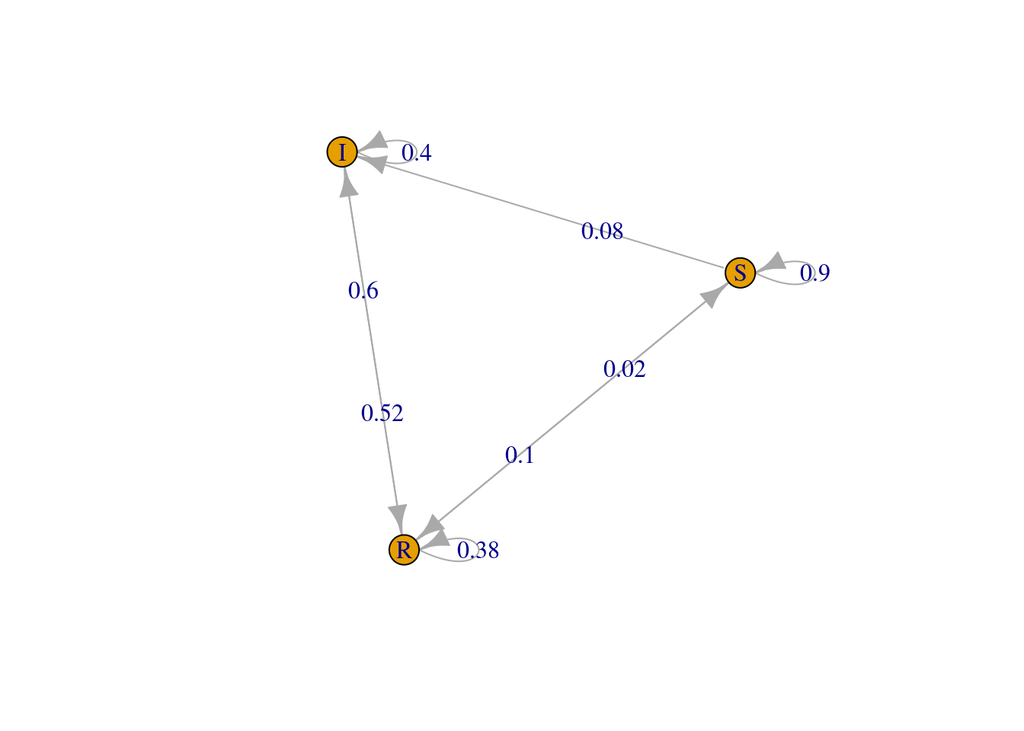

```r
plot(mcEpidemics)
```

## Long Term Behavior

A periodic MC of period that, loosely speaking, means that it can only return to itself after a fixed number of transitions $ k_i>1 $ (or multiple of $k_i$) - else it is aperiodic. The transition matrix is of period 1 - then it’s **aperiodic**

```r
period(mcEpidemics)
```

```
## [1] 1
```

## Asymptotic Properties

This can help us to predict the asymptotic behavior of the system.

In fact, combining both irreducibility and aperiodicity we can state that the system will reach any state in a finite number of steps. That a finite state exists for this MC.

It also mean that it’s distribution will settle down to a defined one, a steady state rather than fluctuating infinitely. This distribution is the following one:

```r
steadyState <- steadyStates(mcEpidemics)
steadyState
```

```
##              S         I         R
## [1,] 0.3333333 0.3333333 0.3333333
```

```r
# asn <- initialDistribution * mcEpidemics
#
# for (i in 1:5) {
#   if (ans == steadyState) {
#     print(i)
#     break
#   }
#   else {
#     ans <- initialDistribution * ans
#   }
# }
```

## Number of Individuals Asymptotically Distributed

We simulate the trend of the MC after many steps

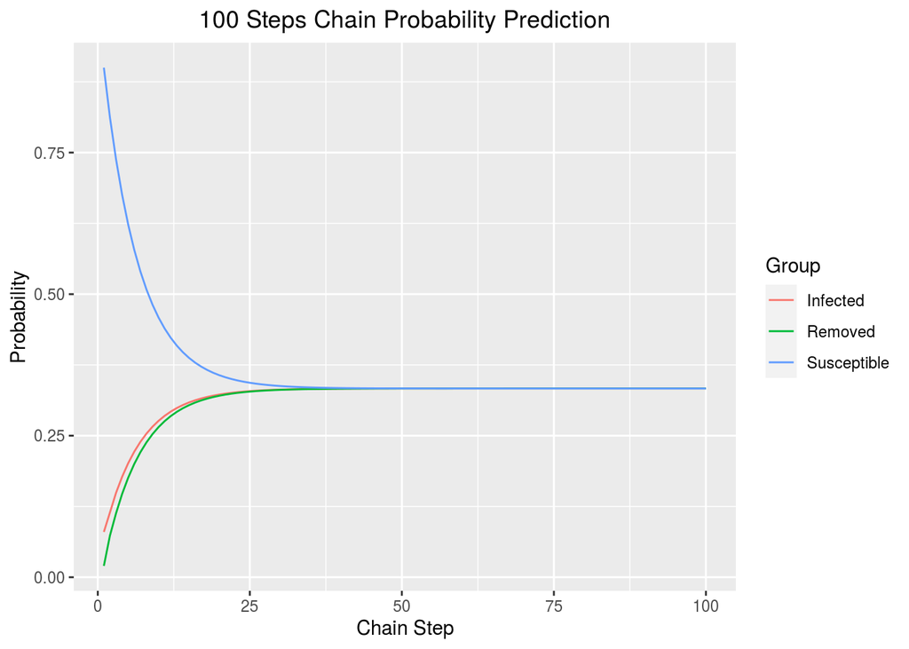

```r
library(ggplot2)

initState <- initialDistribution
manySteps <- 100

# Instantiate probability vectors
P_S <- c()
P_I <- c()
P_R <- c()

# Calculate probabilities for 100 steps.
for(k in 1:100){
  nsteps <- initState * (mcEpidemics ^ k)
  P_S[k] <- nsteps[1,1]
  P_I[k] <- nsteps[1,2]
  P_R[k] <- nsteps[1,3]
}

# Make dataframes and merge them

# S
P_S <- as.data.frame(P_S)
P_S$Group <- 'Susceptible'
P_S$Iter <- 1:manySteps
names(P_S)[1] <- 'Value'

# I
P_I <- as.data.frame(P_I)
P_I$Group <- 'Infected'
P_I$Iter <- 1:manySteps
names(P_I)[1] <- 'Value'

# R
P_R <- as.data.frame(P_R)
P_R$Group <- 'Removed'
P_R$Iter <- 1:manySteps
names(P_R)[1] <- 'Value'

# steps
steps <- rbind(P_S,P_I,P_R)

# Plot the probabilities using ggplot
ggplot(steps, aes(x = Iter, y = Value, col = Group))+
  geom_line() +
  xlab('Chain Step') +
  ylab('Probability') +
  ggtitle(paste0(manySteps,' Steps Chain Probability Prediction', collapse = NULL)) +
  theme(plot.title = element_text(hjust = 0.5))
```

# Conclusion

The number of individuals in each state is calculated through the **expected value** - probability of being in a particular state times the total number of individuals

$ E(X)=P(s_i)*N $

```r
nS_i <- round(steadyState * N)
nS_i
```

```
##         S    I    R
## [1,] 3333 3333 3333
```